# Cumsum and Diff Tricks

Jeff Newmiller

2020-05-24

There are many instances where you want to look for “trigger” status values in a table (data frame) that mark the beginning of a sequence of records that need to be grouped together. Naturally, there are usually corresponding “trigger” values that mark the end of such a group of records. The obvious solution for automating the identification of such groups is to write a while or for loop that sequentially examines each record and uses `if-else` logic to generate a new column in the table that indicates the assignment of each record to an appropriate group. However, in many (but not all) cases such logic can instead be implemented using fast-running vectorized functions by creating a sequence of a few column-wise vectors that lead to generation of such a grouping column using simpler and faster basic operations.

Note that these techniques can be applied in Python as well, using numpy/pandas functions.

```r
suppressPackageStartupMessages({
  library(dplyr)
  library(ggplot2)
  library(kableExtra)
})
theme_set(theme_minimal())
```

## The idea

If we have a timeline, or any real number line, we may be able to figure out when certain things happened, but it may be useful to lump records following those events together.

```r
dta1 <- read.table( text=
"X  Start
 1  1
 2  0
 3  1
 4  0
 5  0
 6  0
 7  1
 8  0
",header=TRUE,as.is=TRUE)
dta1
```

```
##   X Start
## 1 1     1
## 2 2     0
## 3 3     1
## 4 4     0
## 5 5     0
## 6 6     0
## 7 7     1
## 8 8     0
```

Here we have some events at 1, 3, and 7.

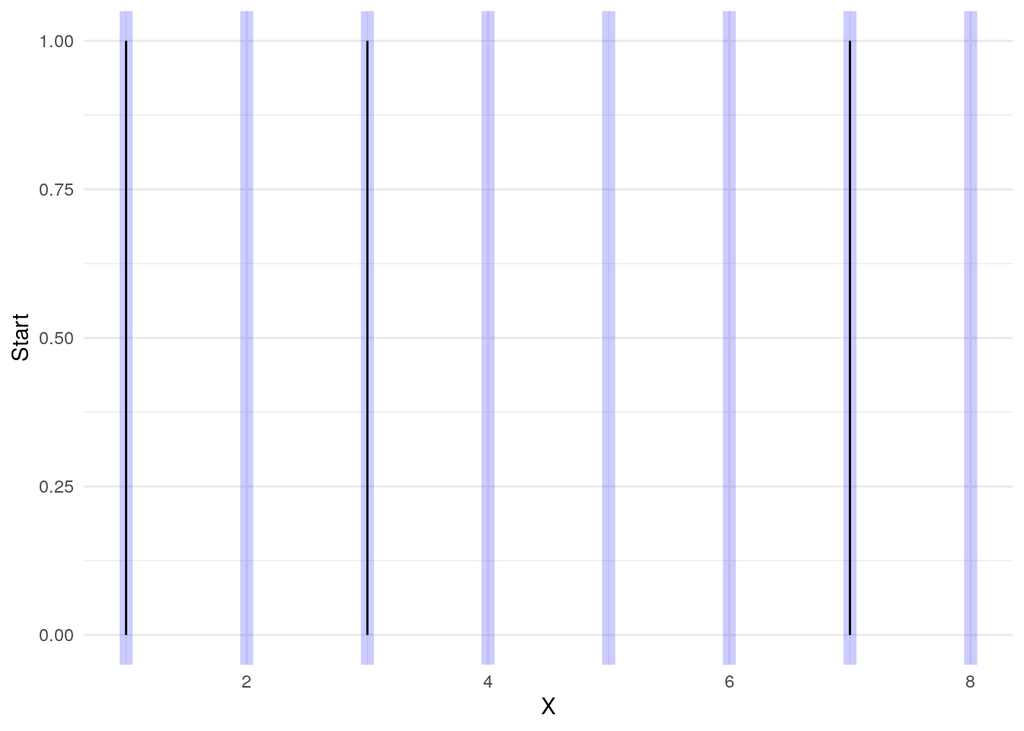

But we would like to group the records together:

| X | Start |
| --- | --- |
| 1 | 1 |
| 2 | 0 |
| 3 | 1 |
| 4 | 0 |
| 5 | 0 |
| 6 | 0 |
| 7 | 1 |
| 8 | 0 |

The trick to marking these records as belonging together is to use `cumsum` on the `Start` events

```r
dta1$G <- cumsum( dta1$Start )
```

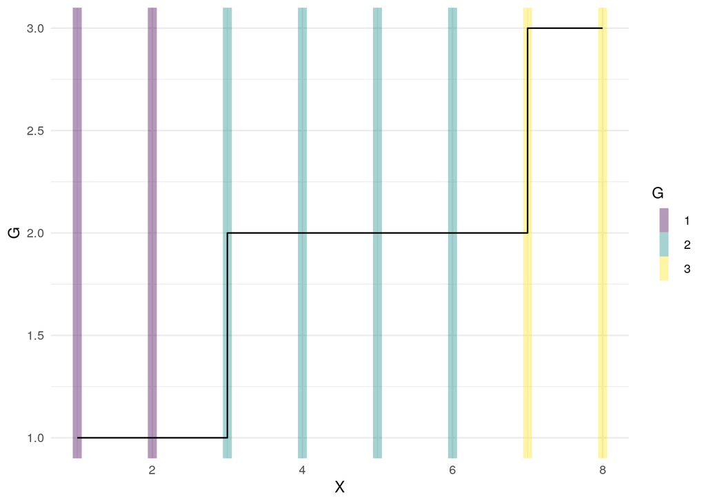

| X | Start | G |
| --- | --- | --- |
| 1 | 1 | 1 |
| 2 | 0 | 1 |
| 3 | 1 | 2 |
| 4 | 0 | 2 |
| 5 | 0 | 2 |
| 6 | 0 | 2 |
| 7 | 1 | 3 |
| 8 | 0 | 3 |

The `G` column can be used in grouped calculations to identify each group of records.

## Intervals

Now we look at a more involved extension of this idea: collapsing records that redundantly specify overlapping intervals.

```r
dta2 <- read.table( text=
"Label Start End
A      5     8
B      2     6
C      9     11
D      14    17
",header=TRUE)
dta2
```

```
##   Label Start End
## 1     A     5   8
## 2     B     2   6
## 3     C     9  11
## 4     D    14  17
```

As we see below, there are parts of the number line that are not identified by these `Start`/`End` pairs (red bars), and there are individual intervals shown by the black bars. Intervals `A` and `B` overlap, so the goal is to represent them by one black bar.

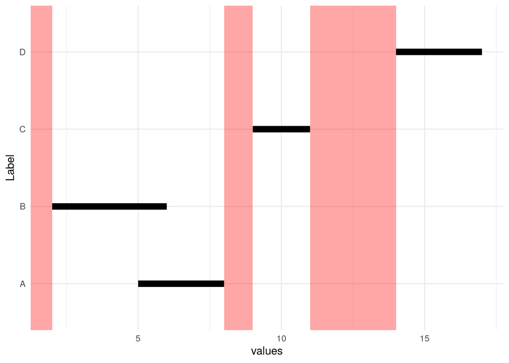

We start by sorting by beginning of interval (`Start`).

```
##   Label Start End
## 1     B     2   6
## 2     A     5   8
## 3     C     9  11
## 4     D    14  17
```

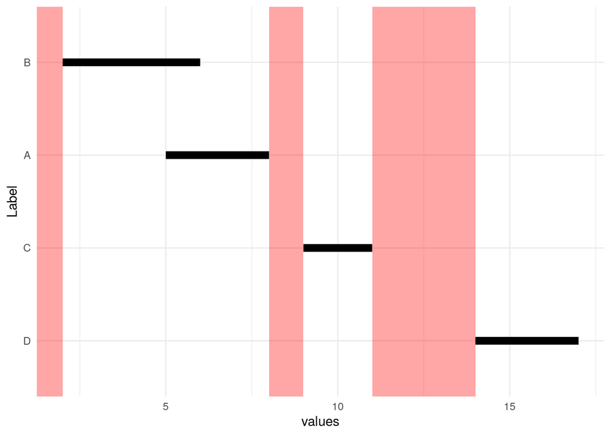

| Label | Start | End |
| --- | --- | --- |
| B | 2 | 6 |
| A | 5 | 8 |
| C | 9 | 11 |
| D | 14 | 17 |

```r
dta2c <- (   dta2b
         %>% mutate( hole = c( Inf, Start[-1]-End[-n()] ) )
         )
dta2c
```

```
##   Label Start End hole
## 1     B     2   6  Inf
## 2     A     5   8   -1
## 3     C     9  11    1
## 4     D    14  17    3
```

Next we identify events… which intervals have holes greater or equal to zero in front of them?

```r
dta2d <- (   dta2c
         %>% mutate( group_start = ( 0 <= hole ) )
         )
dta2d
```

```
##   Label Start End hole group_start
## 1     B     2   6  Inf        TRUE
## 2     A     5   8   -1       FALSE
## 3     C     9  11    1        TRUE
## 4     D    14  17    3        TRUE
```

Now that we have events identified, we can use `cumsum` to identify records that belong together:

```r
dta2e <- (   dta2d
         %>% mutate( group = cumsum( group_start ) )
         )
dta2e
```

```
##   Label Start End hole group_start group
## 1     B     2   6  Inf        TRUE     1
## 2     A     5   8   -1       FALSE     1
## 3     C     9  11    1        TRUE     2
## 4     D    14  17    3        TRUE     3
```

With the `group` column defined, the minimum `Start` and the maximum `End` in each `group` value can be used to form a single interval record.

```r
dta2f <- (   dta2e
         %>% group_by( group )
         %>% summarise( Start = min( Start )
                      , End = max( End )
                      )
         %>% ungroup()
         )
dta2f
```

```
## # A tibble: 3 x 3
##   group Start   End
##   <int> <int> <int>
## 1     1     2     8
## 2     2     9    11
## 3     3    14    17
```

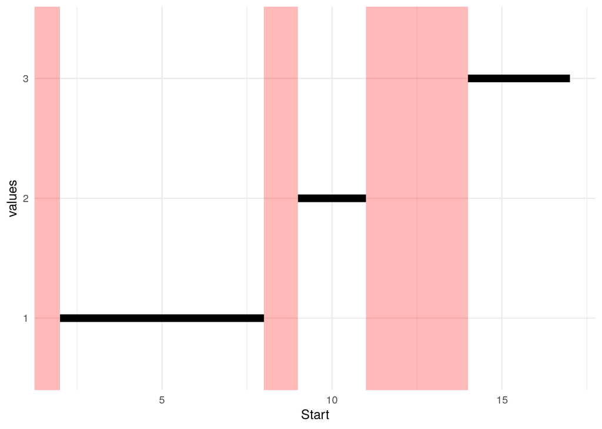

With `dplyr` this series of operations can be piped together instead of built incrementally as we did above to show the intermediate results:

```r
dta2g <- (   dta2
         %>% arrange( Start )
         %>% mutate( hole = c( Inf, Start[-1]-End[-n()] )
                   , group = cumsum( 0 <= hole )
                   )
         %>% group_by( group )
         %>% summarise( Start = min( Start )
                      , End = max( End )
                      )
         %>% ungroup()
         )
dta2g
```

```
## # A tibble: 3 x 3
##   group Start   End
##   <int> <int> <int>
## 1     1     2     8
## 2     2     9    11
## 3     3    14    17
```

## One day (max) separation

```r
library(dplyr)

dta <- read.csv(text=
"id|start|end
1|2015-08-01|2015-12-31
1|2016-01-01|2016-12-31
1|2017-01-01|2017-05-08
2|2014-08-12|2014-12-31
2|2015-01-01|2015-07-23
2|2016-01-12|2016-12-31
2|2017-01-01|2017-08-22
",sep="|",as.is=TRUE
,colClasses=c("numeric","Date","Date"))
```

```r
(   dta
%>% arrange( id, start )
%>% group_by( id )
%>% mutate( hole = c( Inf
                    , as.numeric( start[-1]-end[-n()]
                                , units="days"
                                )
                    )
          , gp = cumsum( 1 < hole )
          )
%>% ungroup
# %>% group_by( id, gp )
# %>% summarise( start = min( start )
#              , end = max( end )
#              )
)
```

```
## # A tibble: 7 x 5
##      id start      end         hole    gp
##   <dbl> <date>     <date>     <dbl> <int>
## 1     1 2015-08-01 2015-12-31   Inf     1
## 2     1 2016-01-01 2016-12-31     1     1
## 3     1 2017-01-01 2017-05-08     1     1
## 4     2 2014-08-12 2014-12-31   Inf     1
## 5     2 2015-01-01 2015-07-23     1     1
## 6     2 2016-01-12 2016-12-31   173     2
## 7     2 2017-01-01 2017-08-22     1     2
```

```r
(   dta
%>% arrange( id, start )
%>% group_by( id )
%>% mutate( hole = c( Inf
                    , as.numeric( start[-1]-end[-n()]
                                , units="days"
                                )
                    )
          , gp = cumsum( 1 < hole )
          )
%>% ungroup
%>% group_by( id, gp )
%>% summarise( start = min( start )
             , end = max( end ))
)
```

```
## # A tibble: 3 x 4
## # Groups:   id [2]
##      id    gp start      end
##   <dbl> <int> <date>     <date>
## 1     1     1 2015-08-01 2017-05-08
## 2     2     1 2014-08-12 2015-07-23
## 3     2     2 2016-01-12 2017-08-22
```